# Bioestadística con R

## Estadística inferencial

## Estadística inferencial

Aprenderemos a hacer **inferencias** basadas en un modelo de muestreo aleatorio.

Usaremos información proveniente de nuestras muestras aleatorias para *inferir* hechos acerca de la población de la que fueron tomadas.

Utilizamos datos para determinar alguna característica de la población original o para medir la precisión de nuestras estimaciones.

## Estadística inferencial

Sabemos que al tomar muestras de una población, nuestros datos son susceptibles a un **error de muestreo.**

Cabe aclarar que este error no solamente tiene que ver con la precisión de medición, si no que surge por el hecho de que no estamos tomando en cuenta los datos de toda la población.

## Error estándar de la media

El **error estándar** mide la magnitud del error de muestreo, es decir, la discrepancia entre \(\overline{x}\) y \(\mu\) utilizando la distribución muestral de \(\overline{X}\).

\[ SE_\overline{X} = \frac{s}{\sqrt{n}} \]

Esta fórmula ya la habíamos visto…

\[ \mu_\overline{X} = \frac{\sigma}{\sqrt{n}} \]

## Error estándar de la media

Normalmente, la diferencia entre \(\mu\) y \(\overline{x}\) es unos cuantos errores estándar. De hecho, encontramos a \(\overline{x}\) a un error estándar de \(\mu\) bastante seguido.

Hay que destacar que el error estándar dependen de la desviación estándar muestral \(s\) y del tamaño de muestra \(n\).

## Error estándar vs. desviación estándar

La desviación estándar describe la **dispersión** de los datos de una muestra.

El error estándar describe la **falta de fidelidad** en la media de una muestra como estimación de la media poblacional, debido al error de muestreo.

Una forma de disminuir el error estándar es incrementando el tamaño de muestra \(n\).

## Error estándar vs. desviación estándar

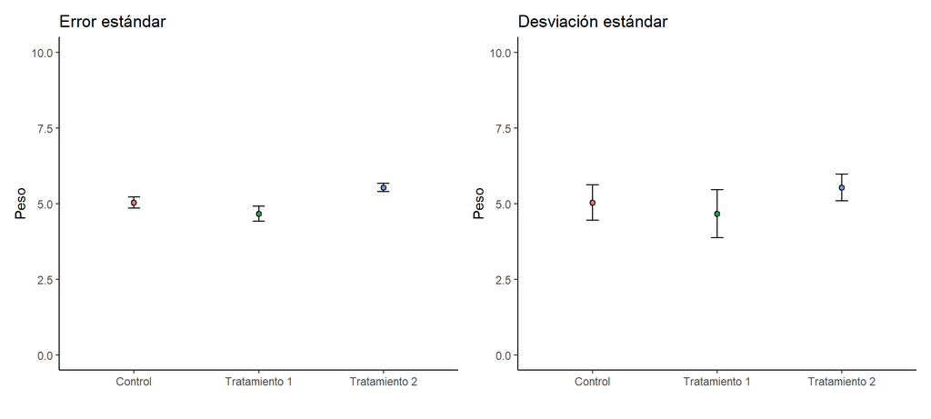

## Intervalos de confianza

## Intervalo de confianza para \(\mu\)

Un **intervalo de confianza** nos sirve para determinar qué tan cerca está de \(\mu\) nuestra media muestral \(\overline{x}\).

Ya que usualmente no podemos medir de manera directa \(\mu\), utilizamos \(\overline{x}\) adicional al error estándar \(SE_\overline{X}\).

\[ \overline{x} \pm {2} \times {SE_\overline{X}} \]

## ¿Por qué utilizar dos veces el error estándar?

Al utilizarlo sabemos que el 95% de las veces \(\mu\) se encontrará en este intervalo. Si utilizáramos solamente un \(SE_\overline{X}\) solamente estaríamos seguros de que \(\mu\) se encuentra en este intervalo el 68% de las veces.

Esta idea está basada en la distribución muestral de \(X\) que vimos en la lección anterior.

Al estandarizar nuestra variable \(X\) y transformarla en valores \(Z\), lo que buscamos es un área de 0.95. Estos valores \(z\) corresponden a -1.96 como límite inferior y 1.96 como limite superior.

## Las matemáticas…

\[ P({-1.96}<{Z}<1.96) = 0.95 \]

\[ P({-1.96}<{\frac{\overline{X}-\mu}{\sigma/\sqrt{n}}}<1.96) = 0.95 \]

\[ P({-1.96\times{\sigma/\sqrt{n}}}<{{\overline{X}-\mu}}<1.96\times{\sigma/\sqrt{n}}) = 0.95 \]

\[ P({-\overline{X}-1.96\times{\sigma/\sqrt{n}}}<{-\mu}<-\overline{X}1.96\times{\sigma/\sqrt{n}}) = 0.95 \]

\[ P({\overline{X}-1.96\times{\sigma/\sqrt{n}}}<{\mu}<\overline{X}1.96\times{\sigma/\sqrt{n}}) = 0.95 \]

\[ \overline{X} \pm 1.96\frac{\sigma}{\sqrt{n}} \]

## Intervalo de confianza para \(\mu\)

Si en este caso, cambiamos \(\sigma\) por \(s\), podemos calcular el intervalo de confianza para nuestra muestra.

William Sealy Gosset, quién publicó sus hallazgos bajo el seudónimo de *Student*, descubrió un método para preservar la interpretación del 95% y desde entonces este método lleva su seudónimo.

Si la muestra proviene de una población normal, y si remplazamos \(\sigma\) del intervalo por \(s\), la interpretación del 95% se puede preservar utilizando como multiplicador la nueva cantidad de \(t_{0.025}\), que está relacionada con una distribución conocida como **distribución \(t\) de Student.**

## Distribución \(t\) de Student

## Distribución \(t\) de Student

La distribución \(t\) de Student es una distribución teórica continua, usada para distintos propósitos en estadística.

depende de una cantidad conocida como **grados de libertad** o \(df\).

La forma de una distribución \(t\) de Student es de campana, similar a la distribución normal, pero con una desviación estándar mayor.

Conforme los grados de libertad aumentan, la curva de una distribución \(t\) de Student se asemeja más a una curva normal (podría decirse que una curva normal es una curva \(t\) de Student con \(df = \infty\)).

## Distribución \(t\) de Student

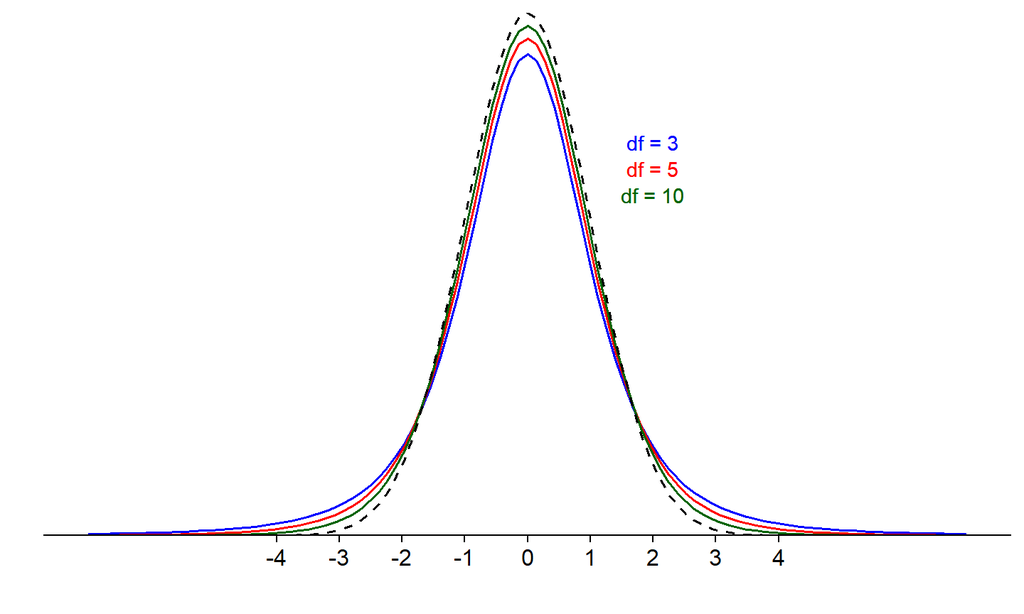

## El valor crítico

La cantidad \(t_{0.025}\) se conoce como **valor crítico al 5% de dos colas** de una distribución \(t\) de Student. El área entre \(-t_{0.025}\) y \(t_{0.025}\) contiene el 95% del área de la curva. Es decir el área debajo de \(-t_{0.025}\) y encima de \(t_{0.025}\) suman en total 5%.

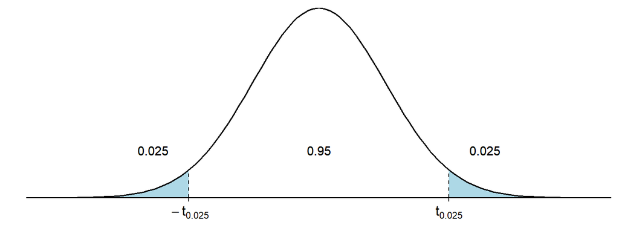

## Las tablas de \(t\)

Existen **tablas de distribución \(t\) de Student** que se utilizan para encontrar los valores críticos acorde con nuestros grados de libertad. Al igual que la distribución binomial, Poisson y normal, *R* viene con funciones para la distribución \(t\) de Student.

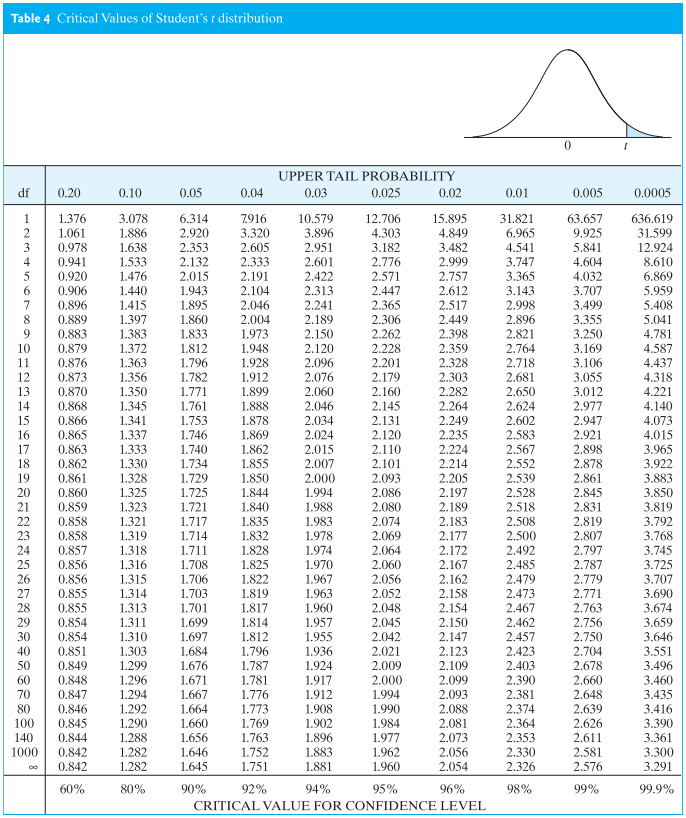

## Funciones de la distribución \(t\) de Student

- **dt()** nos da un valor de densidad determinado de la distribución de \(t\) (PDF).
- **pt()** nos da un valor de densidad acumulado hasta cierto punto en la distribución de \(t\) (CDF).
- **qt()** toma el valor de densidad que le ponemos como primer argumento y nos da como regreso un número cuya densidad acumulada empate con el valor de densidad ingresado.
- **rt()** genera cierta cantidad de número aleatorios de acuerdo al valor de densidad.

Sin embargo en este caso, en lugar de contar con el argumento *n* para el tamaño de muestra, contamos con otro argumento *df* para los grados de libertad.

## Requisitos de la distribución \(t\) de Student

Para poder utilizar el método \(t\) de Student, se necesitan cumplir ciertas condiciones:

- Las muestras deben de ser **aleatorias**.
- Las observaciones de la muestra deben ser **independientes** unas de otras.
- Si \(n\) es pequeña, la distribución de la población debe ser **aproximadamente normal.**
- Si \(n\) es grande, la distribución de la población **no necesita ser normal.**

## Construcción del intervalo de confianza para \(\mu\)

El primer paso para construir nuestro intervalo de confianza es elegir nuestro nivel de confianza (generalmente es 95% pero esto no quiere decir que siempre tenga que ser así).

Si quisiéramos un nivel de confianza de 90% utilizamos un valor crítico de \(t_{0.05}\).

Por regla general, el valor de crítico de \(t\) será igual a \(t_{\alpha/2}\), donde \(\alpha\) es el nivel de significancia que el investigador elige.

Básicamente \(\alpha\) nos protege de un error conocido como **error tipo I.**

Cuando nos interesan ambas colas de la distribución de \(t\) de Student, dividimos el valor \(\alpha\) entre dos (correspondiente a las dos colas).

## Construcción del intervalo de confianza para \(\mu\)

Después tenemos que establecer los límites de nuestro intervalo utilizando la siguiente fórmula…

\[ \overline{x} \pm t_{\alpha/2}\frac{s}{\sqrt{n}} \]

Para calcular los grados de libertad…

\[ df = n - 1 \]

## ¿Por qué n - 1?

Las desviaciones (\(x_i - \overline{x}\)) deben de sumar 0 en total, por lo que solamente \(n - 1\) de estas desviaciones puede variar *libremente*, ya que al conocer el valor del resto de las desviaciones, la última queda *determinada,* aunque no la conozcamos.

## Ejemplo con Mariposa Monarca

Una muestra del área de las alas obtenida de una población de la Mariposa Monarca (*Danaus plexippus*) de 14 ejemplares tiene una media \(\overline{x} = 32.8143 \space cm^2\) y una desviación estándar \(s = 2.4757 \space cm^2\). Sabemos que los datos provienen de una población con distribución normal.

¿Cuál sería el intervalo de confianza al 95% para esta muestra?

Lo primero que tenemos que hacer es calcular los grados de libertad.

\[ df = n - 1 = 14 - 1 = 13 \]

## Ejemplo con Mariposa Monarca

Como queremos un intervalo de confianza al 95%, \(\alpha = 0.05\) y \(t_{\alpha/2} = t_{0.025}\).

Para encontrar este valor podemos buscarlo en una tabla de \(t\) o utilizar las funciones de **R.**

```r
qt(0.025, 13, lower.tail = FALSE)
```

```
## [1] 2.160369
```

Por lo tanto, el intervalo de confianza es…

\[ 32.8143 \pm {2.16} \times {\frac{2.4757}{\sqrt{14}}} \]

\[ 32.8143 \pm {2.16} \times {0.6617} \]

\[ 32.8143 \pm 1.4293 \]

## Ejemplo con Mariposa Monarca

```r
32.8143 - 2.160*(2.4757/sqrt(14))
```

```
## [1] 31.38512
```

```r
32.8143 + 2.160*(2.4757/sqrt(14))
```

```
## [1] 34.24348
```

## Aleatoriedad del intervalo

Una cosa importante a destacar es que es el propio intervalo de confianza es el que es **aleatorio**. Si consideramos intervalos de confianza al 95%, entonces…

\[ P(La\space siguiente\space muestra\space nos\space dará\space un\space intervalo\space de\space confianza\space que\space \\ contenga\space a\space \mu) = 0.95 \]

Si hiciéramos un meta-estudio y construyéramos un intervalo de confianza a 95% para cada una de las muestras, entonces el 95% de los intervalos de confianza contendrán a \(\mu\).

El nivel de confianza (90%, 95%, 99%) es una propiedad del método más que de un intervalo particular.

## Intervalos de confianza unilaterales

Este tipo de intervalos de confianza se obtienen cuando solamente nos interesa el límite inferior o superior.

Supongamos que queremos construir un intervalo de confianza con un límite inferior al 95%.

Mientras que un intervalo de confianza bilateral está basado en usar el valor \(\pm t_{0.025}\), un intervalo de confianza al 95% de un solo lado (en este caso inferior) solamente se preocupa por el área bajo la curva del lado correspondiente, entonces no tenemos que realizar \(\alpha/2\) para el valor crítico de \(t\).

## Intervalo de confianza unilateral para las Mariposas Monarca

Ya que \(P(-t_{0.05} > t > \infty) = 0.95\), para un intervalo de confianza unilateral al 95% utilizamos un valor de \(-t_{0.05}\). Para un intervlao de confianza con límite inferior…

\[ \overline{x} - t_{\alpha}{SE_{\overline{X}}} \]

Por el contrario, para un intervalo con límite superior…

\[ \overline{x} + t_{\alpha}{SE_{\overline{X}}} \]

## Comparación de medias

## Comparación de dos medias

Cuando queremos comparar dos muestras que provienen de supuestamente poblaciones distintas, podemos realizar las comparaciones utilizando:

- Las medias de las muestras
- Sus desviaciones estándar
- La forma de su distribución

Para comprar la media de dos muestras, es natural considerar la diferencia entre ellas.

\[ \overline{X}_1 - \overline{X}_2 \]

Esta cantidad es un estimado de la diferencia entre las poblaciones (\(\mu_1 - \mu_2\)).

## Error estándar de \(\overline{X}_1 - \overline{X}_2\)

Para caracterizar el error de muestreo de esta estimación, debemos conocer el error estándar entre la diferencia de (\(\overline{X}_1 - \overline{X}_2\)).

\[ SE_{(\overline{X}_1 - \overline{X}_2)} = \sqrt{\frac{s^2_1}{n_1} + \frac{s^2_2}{n_2}} \]

Otra forma de representar la fórmula es de la siguiente manera

\[ SE_{(\overline{X}_1 - \overline{X}_2)} = \sqrt{SE^2_1 + SE^2_2} \]

En donde \(SE_1 = SE_{\overline{X}_1} = \frac{s_1}{\sqrt{n_1}}\) y \(SE_2 = SE_{\overline{X}_2} = \frac{s_2}{\sqrt{n_2}}\).

## Intervalo de confianza para \(\mu_1 - \mu_2\)

Podemos comprar las medias de dos muestras construyendo un intervalo de confianza para la diferencia de las medias. La fórmula para un intervalo de confianza de la diferencia de las medias es bastante similar a la usada para construir uno para una muestra…

\[ (\overline{X}_1 - \overline{X}_2) \pm t_{\alpha/2} SE_{(\overline{X}_1 - \overline{X}_2)} \]

El valor crítico de \(t_{\alpha/2}\) es determinado a partir de la distribución \(t\) de Student utilizando los grados de libertad que en este caso se calculan de la siguiente manera…

\[ df = \frac{(SE^2_1 + SE^2_2)^2}{SE^4_1/(n_1 - 1) + SE^4_2/(n_2 -1)} \]

## En cuanto a los grados de libertad…

Otros métodos se basan en obtener los grados de libertad utilizando el número más pequeño entre (\(n_1 - 1\)) y (\(n_2 - 1\)) o también se pueden obtener haciendo \(n_1 + n_2 - 2\).

## Ejemplo… Mariposas Monarca, ¡otra vez!

Varios biólogos creen que el tórax de las mariposas monarca macho es mayor que el de las hembras. Una muestra de 7 machos y 8 hembras dan los resultados de la tabla siguiente…

Peso del torax (mg)

| Machos | Hembras |
| --- | --- |
| 67 | 73 |
| 73 | 54 |
| 85 | 61 |
| 84 | 63 |
| 78 | 66 |
| 63 | 57 |
| 80 | 75 |
|  | 58 |

## Ejemplo… Mariposas Monarca, ¡otra vez!

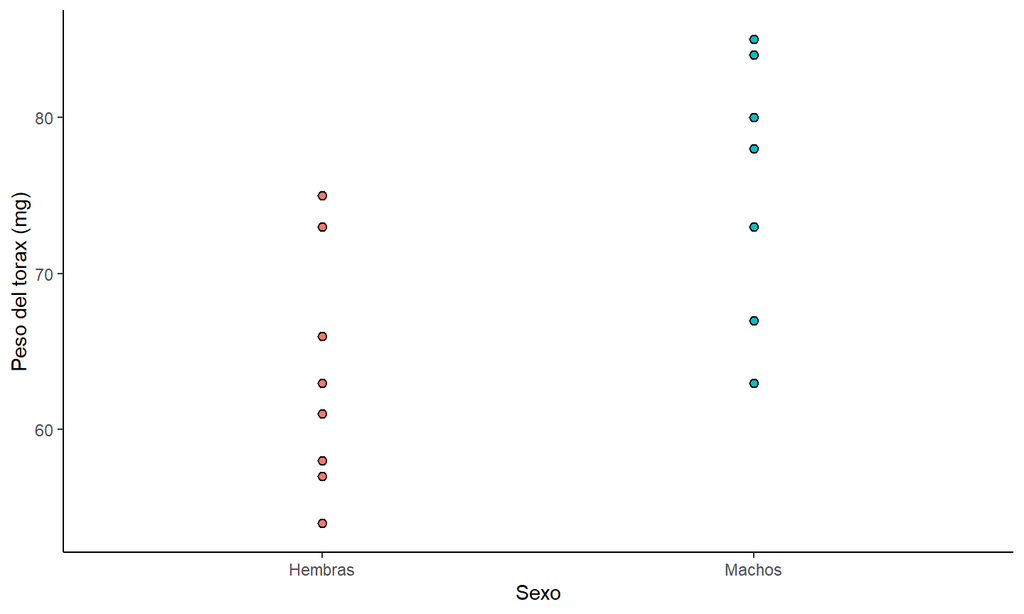

## Ejemplo… Mariposas Monarca, ¡otra vez!

Ahora tendremos que calcular ciertos valores para estos datos, como las medias y desviaciones estándar de cada grupo.

```r
Grupo <- c(rep("Machos", 7), rep("Hembras", 8))
Peso <- c(67, 73, 85, 84, 78, 63, 80, 73, 54, 61, 63, 66, 57, 75, 58)
Sample <- data.frame(Grupo, Peso)
Sample
```

```
##      Grupo Peso
## 1   Machos   67
## 2   Machos   73
## 3   Machos   85
## 4   Machos   84
## 5   Machos   78
## 6   Machos   63
## 7   Machos   80
## 8  Hembras   73
## 9  Hembras   54
## 10 Hembras   61
## 11 Hembras   63
## 12 Hembras   66
## 13 Hembras   57
## 14 Hembras   75
## 15 Hembras   58
```

## Ejemplo… Mariposas Monarca, ¡otra vez!

Ahora para obtener el intervalo de confianza no hace falta que hagamos todas las fórmulas para obtener los grados de libertad, el error estándar, etc. Basta con usar la función **t.test()** seguido de **$conf.int** para obtener nuestro intervalo de confianza.

```r
t.test(Peso ~ Grupo, Sample)$conf.int
```

```
## [1] -21.353087  -3.325484
## attr(,"conf.level")
## [1] 0.95
```

Como podemos ver nuestro intervalo se encuentra entre (\(3.3, \space 21.4\)) para un nivel de significancia del 95%.

## ¿Cómo se interpreta esto?

De acuerdo a nuestro intervalo de confianza, podemos estar 95% seguros de que la media poblacional del tórax de los machos de Mariposa Monarca (\(\mu_1\)) es más grande que la de las hembras (\(\mu_2\)) por una cantidad tan pequeña como 3.3 mg o tan grande como 21.4 mg.

Si quisiéramos ajustar el nivel de confianza de nuestro intervalo, también podemos hacerlo.

```r
t.test(Peso ~ Grupo, Sample, conf.level = 0.9)$conf.int
```

```
## [1] -19.716479  -4.962093
## attr(,"conf.level")
## [1] 0.9
```

Un intervalo de confianza al 90% se encuentra entre (\(5.0, \space 19.7\)).

## Pruebas de hipótesis

## Pruebas de hipótesis

¿Qué tan diferentes tienen que ser dos muestras para concluir que las poblaciones de las que vienen son distintas? Una aproximación que podemos hacer es comparar las medias de las dos muestras y ver qué tanto difieren comparándolo con la diferencia que esperaríamos si fuese azar.

## \(t\)-test

La idea general es formular una hipótesis para ver si \(\mu_1\) y \(\mu_2\) difieren y ver la información que tenemos de nuestras muestras para ver si se apoya esta hipótesis.

La hipótesis de que \(\mu_1\) y \(\mu_2\) no son iguales es, de manera general, nuestra **hipótesis alternativa** y se abrevia como \(H_A\).

\[ H_A: \mu_1 \neq \mu_2 \]

La antítesis de esta hipótesis se conoce como **hipótesis nula** y se abrevia como \(H_0\).

\[ H_0: \mu_1 = \mu_2 \]

## Estadístico de prueba

Una **estadístico de prueba de hipótesis** o **estadístico de prueba** nos ayuda a corroborar la fuerza de la evidencia presentada en los datos en favor de la \(H_A\).

Ya que la \(H_0\) dice que las medias de las poblaciones son iguales, esperaríamos que esa diferencia fuese 0.

\[ H_0: \mu_1 = \mu_2 \longleftrightarrow H_0: \mu_1 - \mu_2 = 0 \]

La \(H_A\) dice que la diferencia entre las medias no es igual a 0.

\[ H_0: \mu_1 \neq \mu_2 \longleftrightarrow H_0: \mu_1 - \mu_2 \neq 0 \]

## Estadístico de \(t\)

La **prueba de \(t\)** es un método que nos ayuda a elegir entre ambas hipótesis. Para hacer un análisis como este, primero necesitamos computar el **estadístico de \(t\)**.

\[ t_s = \frac{(\overline{x}_1 - \overline{x}_2) - 0}{SE_{(\overline{X}_1 - \overline{X}_2)}} \]

Mide que tan larga es la diferencia de las medias de la diferencia que esperaríamos si la \(H_0\) fuese verdad \((\overline{x}_1 - \overline{x}_2) - 0\), expresada en relación con el error estándar de la diferencia \(SE_{(\overline{X}_1 - \overline{X}_2)}\) (la cantidad de variación que esperaríamos ver en la diferencias de muestras aleatorias).

Se resta 0 en la fórmula, ya que es la diferencia que esperamos encontrar entre ambas medias si la \(H_0\) es verdadera.

## Ejemplo

Investigadores están interesados en los efectos que produce el tolueno. Para esto, midieron las concentraciones de varios químicos en el cerebro de ratas que habían sido expuestas a tolueno y ratas que no habían sido expuestas (control). En la siguiente tabla se muestran las concentraciones de norepinefrina (NE) de la región de la médula del cerebro. La \(H_0\) de los investigadores es que el tolueno no tiene efecto en la concentración de NE en la médula de las ratas. Por ende, la \(H_A\) es que el tolueno tiene un efecto en la médlua de las ratas.

```r
set.seed(123)
Tolueno <- round(rnorm(10, 540.8, 66.1), 1)
Control <- round(rnorm(10, 444.2, 69.6), 1)
ex1 <- data.frame(Control, Tolueno)
```

| Control | Tolueno |
| --- | --- |
| 529.4 | 503.8 |
| 469.2 | 525.6 |
| 472.1 | 643.8 |
| 451.9 | 545.5 |
| 405.5 | 549.3 |
| 568.6 | 654.2 |
| 478.9 | 571.3 |
| 307.3 | 457.2 |
| 493.0 | 495.4 |
| 411.3 | 511.3 |

## Ejemplo

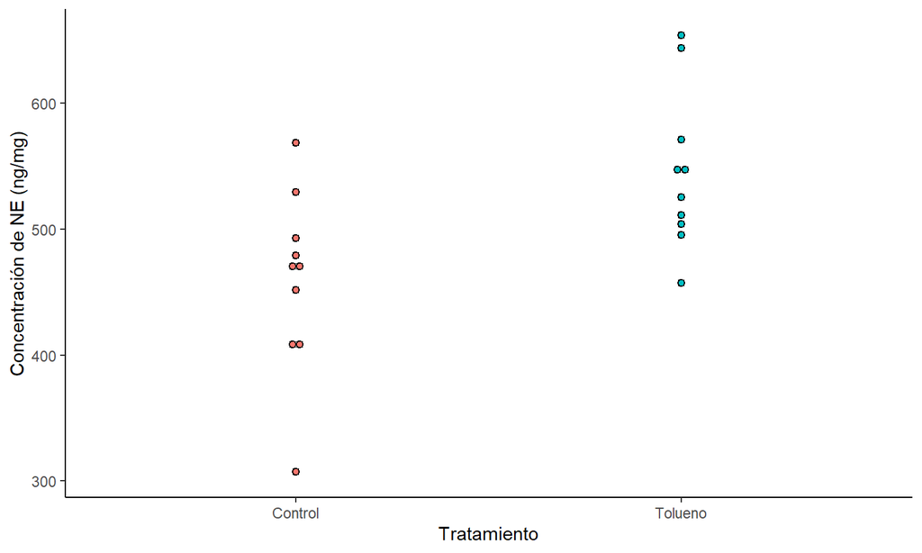

## Ejemplo

En este caso tenemos que conocer la desviación estándar y la media de nuestros datos. Para esto podemos usar la librería de **dplyr** y la función **gather()** que reacomoda los datos de nuestro data frame.

```r
ex2 <- gather(ex1, Grupo, Conc)
ex3 <- ex2 %>% group_by(Grupo) %>% summarise(n = n(), Media = mean(Conc), SD = sd(Conc), SE = SD/sqrt(n))
ex3
```

```
## # A tibble: 2 x 5
##   Grupo       n Media    SD    SE
##   <chr>   <int> <dbl> <dbl> <dbl>
## 1 Control    10  459.  72.3  22.9
## 2 Tolueno    10  546.  63.0  19.9
```

Listo, tenemos nuestra media \(\overline{x}\), desviación estándar \(s\) y error estándar \(SE\) para el grupo control y el grupo tratado con tolueno. Ahora procedemos a aplicar la fórmula para encontrar nuestro estadístico \(t\). Primero debemos calcular el error estándar de (\(\overline{X}_1 - \overline{X}_2\)).

\[ SE_{(\overline{X}_1 - \overline{X}_2)} = \sqrt{\frac{63.04^2}{10} + \frac{72.26^2}{10}} \]

## Aplicación del estadístico de \(t\)

Posteriormente aplicaríamos la fórmula para encontrar el estadístico \(t\).

\[ t_s = \frac{(545.74 - 458.72) - 0}{SE_{(\overline{X}_1 - \overline{X}_2)}} \]

Sin embargo, gracias a la función **t.test** no es necesario que hagamos este procedimiento paso a paso. Por ejemplo, si queremos obtener el estadístico \(t\)…

```r
t.test(Conc ~ Grupo, ex2)$statistic
```

```
##         t
## -2.869561
```

Si agregamos **$statistic** al final de nuestra función obtenemos el estadístico de \(t\) que en este caso es 2.87.

## ¿Cómo sabemos si aceptar o rechazar la \(H_0\)?

Si la \(H_0\) es verdadera, la distribución muestral de \(t_s\) se aproximará a una distribución \(t\) de Student.

La esencia de de la prueba de \(t\) es ver en qué parte de la distribución \(t\) de Student cae el estadístico \(t_s\).

Si cae cercano al centro, entonces la evidencia de los datos es compatible con la \(H_0\).

Si \(t_s\) cae en alguna de las colas, entonces, la evidencia de los datos es compatible con la \(H_A\) y una observación como la obtenida no puede explicarse meramente por azar.

## El valor p

Para juzgar si nuestro valor \(t_s\) cae en la cola de la distribución \(t\) de Student, usamos un valor conocido como valor p.

Puede definirse como el área bajo la curva de una distribución \(t\) de Student en cualquiera de las colas que se encuentra más allá de \(-t_s\) o \(t_s\) como se muestra en la siguiente figura…

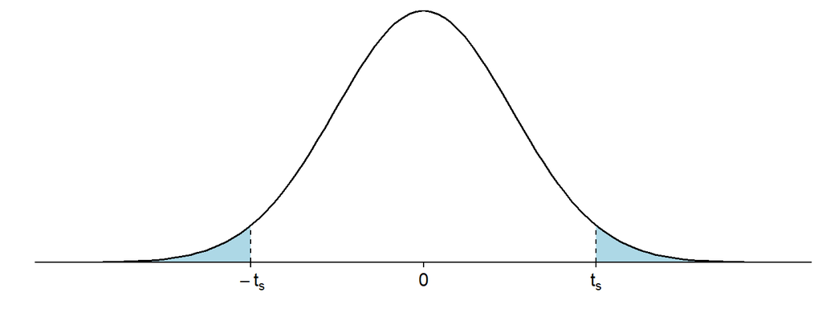

## El valor p

Otra forma de definir el valor p es como la probabilidad de obtener un valor tan extremo como el observado si la \(H_0\) fuera verdadera.

Para calcular el valor p necesitamos encontrar el área bajo la distribución \(t\) de Student que se encuentre más allá de \(\pm SE_{\overline{X}_1 - \overline{X}_2}\). Afortunadamente, la función **t.test()** también nos da el valor p. Podemos corroborar esto a mano.

```r
t.test(Conc ~ Grupo, ex2)$parameter
```

```
##      df
## 17.6748
```

## El valor p

Como podemos ver, para nuestros datos tenemos 17.67 grados de libertad. Entonces simplemente en la distribución \(t\) de Student buscamos el área correspondiente para un valor \(t_s = 2.87\) con \(df = 17.67\).

```r
pt(2.87, 17.67, lower.tail = F) + pt(-2.87, 17.67, lower.tail = T)
```

```
## [1] 0.01032002
```

Como en este caso se trata de un valor p de dos colas, tenemos que sumar el área que obtenemos de la cola inferior y superior. Por ende, nuestro \(valor \space p = 0.0103\).

Afortunadamente no tenemos que hacer esto cada vez que realizamos una prueba de \(t\). Simplemente escribimos **$p.value** al final de nuestro comando.

```r
t.test(Conc ~ Grupo, ex2)$p.value
```

```
## [1] 0.0103277
```

## Interpretación del valor p

Un valor p cercano a 1 indica que el valor \(t_s\) se encuentra cercano al centro de la distribución \(t\), que resultaría en una falta de evidencia para la \(H_A\).

Un valor p cercano a 0 indica que el valor \(t_s\) se encuentra en una de las colas de la distribución \(t\), lo que daría evidencia para la \(H_A\).

## ¿Cuánto es suficiente?

Para esto necesitamos elegir un **nivel de significancia** o \(\alpha\) (que vimos anteriormente en la construcción de intervalos de confianza). Este valor lo elige, generalmente, quién realiza la decisión acerca del estudio.

Valores \(\alpha\) comunes son \(\alpha = 0.1, \space 0.05, \space 0.01\). Si nuestro valor p es menor o igual a nuestro alfa (\(valor \space p \leq \alpha\)) nuestros datos muestran evidencia de una diferencia **estadísticamente significativa** a favor de \(H_A\). Decimos que la \(H_0\) se rechaza.

Si por el contrario el valor p es mayor que nuestro alfa (\(valor \space p > \alpha\)), decimos que hay insuficiente evidencia para decir que \(H_A\) es verdad, por lo tanto no se rechaza la \(H_0\).

## La función **t.test()**

¿Cómo podemos ver toda está información? Bueno, si no agregamos ningún valor al final de nuestro comando **t.test(),** obtenemos toda la información condensada.

```r
t.test(Conc ~ Grupo, ex2)
```

```
##
##  Welch Two Sample t-test
##
## data:  Conc by Grupo
## t = -2.8696, df = 17.675, p-value = 0.01033
## alternative hypothesis: true difference in means between group Control and group Tolueno is not equal to 0
## 95 percent confidence interval:
##  -150.81499  -23.22501
## sample estimates:
## mean in group Control mean in group Tolueno
##                458.72                545.74
```

## El paquete **broom**

Si quisieramos exportar esto en una tabla podemos utilizar la librería **broom.**

```r
library(broom)
t_test <- broom::tidy(t.test(Conc ~ Grupo, ex2))
t_test
```

```
## # A tibble: 1 x 10
##   estimate estimate1 estimate2 statistic p.value parameter conf.low conf.high
##      <dbl>     <dbl>     <dbl>     <dbl>   <dbl>     <dbl>    <dbl>     <dbl>
## 1    -87.0      459.      546.     -2.87  0.0103      17.7    -151.     -23.2
## # ... with 2 more variables: method <chr>, alternative <chr>
```

## Ejemplo

[figure not shown]

## ¿Y si no encontramos evidencias significativas?

Incluso cuando nuestro valor p no muestra diferencias significativas, esto no quiere decir esto que la \(H_A\) no sea verdadera.

- **Tipo de error I:** Cuando decimos que los datos proveen evidencia significativa a favor de la \(H_A\), cuando en realidad \(H_0\) es verdad. Este tipo de error se contrarresta cuando elegimos nuestro \(\alpha\).
- **Tipo de error II:** cuando la \(H_A\) es verdadera, pero no obtenemos suficiente información que demuestre esto. Las muestras con tamaños de muestra pequeños son particularmente vulnerables a este tipo de error. La probabilidad de cometer este tipo de error se conoce como \(\beta\).

## Tipo de error II

La posibilidad de no cometer un error tipo II cuando la \(H_A\) es verdadera se conoce como **poder.**

\[ Poder = 1 - \beta = P(evidencia \space significativa \space para \space H_{A}) \space si \space H_{A} \space es \space verdad \]

## Prueba de \(t\) de una cola

## Prueba de \(t\) de una cola

En caso de que tengamos una **hipótesis direccional** en la que nos interese solamente una de las dos colas de la distribución de \(t\), realizamos un \(t\) test de una cola.

Las \(H_A\) podrían ser \(H_{A}: \mu_1 > \mu_2\) o \(H_{A}: \mu_1 < \mu_2\).

Lo primero es checar la direccionalidad: ¿Nos interesa la parte inferior o superior de la distribución de \(t\)?

Después de eso, ver hacia que lado se desvían los datos. Si nuestros datos se desvían en dirección de la \(H_A\) entonces podemos seguir con el procedimiento.

## El valor p

El valor p de una prueba de \(t\) de una cola será el área que se encuentre más allá de \(t_s\).

Para hacer una prueba de una cola en R simplemente necesitamos cambiar un argumento en **t.test(alternative = “greater”)** o **t.test(alternative = “less”).**

```r
t.test(Conc ~ Grupo, ex2, alternative = "less")
```

```
##
##  Welch Two Sample t-test
##
## data:  Conc by Grupo
## t = -2.8696, df = 17.675, p-value = 0.005164
## alternative hypothesis: true difference in means between group Control and group Tolueno is less than 0
## 95 percent confidence interval:
##       -Inf -34.38172
## sample estimates:
## mean in group Control mean in group Tolueno
##                458.72                545.74
```

## El valor p

```r
t.test(Conc ~ Grupo, ex2, alternative = "greater")
```

```
##
##  Welch Two Sample t-test
##
## data:  Conc by Grupo
## t = -2.8696, df = 17.675, p-value = 0.9948
## alternative hypothesis: true difference in means between group Control and group Tolueno is greater than 0
## 95 percent confidence interval:
##  -139.6583       Inf
## sample estimates:
## mean in group Control mean in group Tolueno
##                458.72                545.74
```

Que existan **diferencia significativas** no quiere decir que el efecto sea realmente **importante.** Una prueba de hipótesis solamente responde a la pregunta *¿Hay suficiente diferencia entre ambas muestras como para inferir que vinieron de dos poblaciones distintas?* Sin embargo no nos dice qué tan grande o importante es la diferencia.

## Tamaño de efecto

Para medir la importancia de una diferencia uno debe de considerar la magnitud de la diferencia. El **tamaño de efecto** de un estudio es la diferencia entre \(\mu_{1}\) y \(\mu_{2}\), en relación con la desviación estándar de una de las poblaciones.

\[ Tamaño \space de \space efecto = \frac{|{\overline{x}_1-\overline{x}_2}|}{\sigma} \]

Los resultados están dados en desviaciones estándar y el valor se conoce como **d de Cohen**. Para calcular la d de Cohen necesitamos un paquete estadístico llamado **effsize** y la función **cohen.d().**

## Tamaño de efecto

```r
library(effsize)
cohen.d(Conc ~ Grupo, data = ex2, pooled_sd = F)
```

```
##
## Cohen's d
##
## d estimate: -1.283307 (large)
## 95 percent confidence interval:
##      lower      upper
## -2.3150540 -0.2515596
```

## Tamaño de efecto

La ventaja de esta función es que nos dice si nuestro tamaño de efecto es grande o pequeño.

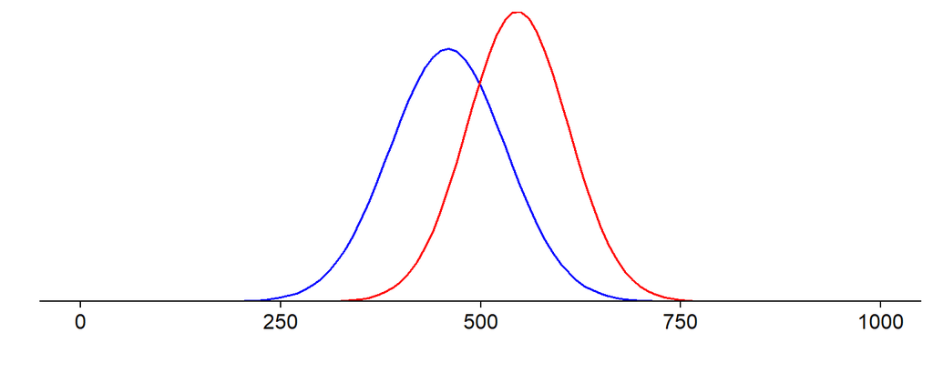

## Prueba de Wilcoxon-Mann-Whitney

## Prueba de Wilcoxon-Mann-Whitney

Compra dos muestras incluso cuando las distribuciones de las poblaciones no son normales.

Este tipo de pruebas no se enfocan en un parámetro particular como la media o la mediana, por esta razón se conocen como pruebas **no paramétricas.**

Una \(H_0\) generalmente empleada es que las distribuciones de \(X_1\) y \(X_2\) son iguales, y la \(H_A\) es que la distribución de \(X_1\) es distinta a la distribución de la población \(X_2\).

Recomendable aplicarla cuando tenemos datos que no se distribuyen de manera normal aunque realicemos transformaciones (como logaritmos u otra transformación). El estadístico de esta prueba se simboliza como \(U_s\) y mide el grado de separación entra ambas muestras.

## Prueba de Wilcoxon-Mann-Whitney

1. Lo primero es acomodar los datos en orden, de menor a mayor para ambas muestras.
2. Posteriormente determinamos \(K_1\) y \(K_2\). Para \(K_1\), contamos el número de observaciones en la muestra 2 que son más pequeñas que la muestra 1. Si hay observaciones que sean iguales para ambas muestras, se cuenta como 1/2 punto. Luego contamos para \(K_2\) el número de observaciones en la muestra 1 que son menores que la muestra 2 y de igual forma, 1/2 si hay alguna observación con valor igual.
3. Para corroborar si nuestros cálculos son correctos la suma de \(K_1\) y \(K_2\) debe ser igual al producto de \(n_1 \times n_2\).
4. El estadístico \(U_s\) va a ser el más grande de los dos \(K_1\) o \(K_2\).
5. Para encontrar el valor p se utilizan tablas de U. Aunque en **R** es más sencillo, utilizando la función **wilcox.text().**

## Ejemplo…

En un estudio farmacéutico, investigadores midieron la concentración de dopamina en el cerebro de seis ratas expuestas a tolueno y seis ratas que funcionaron como control.

```r
Tolueno1 <- c(3420, 2314, 1911, 2464, 2781, 2803)
Control1 <- c(1820, 1843, 1397, 1803, 2539, 1990)

Dopamina <- data.frame(Tolueno1, Control1)
```

| Tolueno | Control |
| --- | --- |
| 3420 | 1820 |
| 2314 | 1843 |
| 1911 | 1397 |
| 2464 | 1803 |
| 2781 | 2539 |
| 2803 | 1990 |

| Grupo | n | Media | SD | SE |
| --- | --- | --- | --- | --- |
| Control1 | 6 | 1898.667 | 371.073 | 151.490 |
| Tolueno1 | 6 | 2615.500 | 513.798 | 209.757 |

## Ejemplo…

```r
Dopamina <- gather(Dopamina, Tratamiento, Concentracion) #Organizamos los datos de manera que se puedan trabajar.

wilcox.test(Concentracion ~ Tratamiento, data = Dopamina)
```

```
##
##  Wilcoxon rank sum exact test
##
## data:  Concentracion by Tratamiento
## W = 4, p-value = 0.02597
## alternative hypothesis: true location shift is not equal to 0
```

## Comparación de muestras pareadas

## Comparación de muestras pareadas

En esta ocasión vamos a considerar dos muestras que no son independientes entre sí, si no que se encuentran **pareadas.** En un diseño pareado, las observaciones de (\(X_1, X_2\)) ocurren en pares.

Esto quiere decir que las observaciones tienen más en común entre sí que con otros pares.

## Prueba de \(t\) pareada

En lugar de considerar a \(X_1\) y \(X_2\) por separado, consideramos su diferencia \(D\).

\[ D = X_1 - X_2 \]

Cuando tenemos datos pareados, son las diferencias en sí lo que queremos registrar. La media de \(D\) es \(\overline{D}\) y de igual manera se obtiene como una diferencia entre las medias de ambas muestras.

\[ \overline{D} = \overline{X}_1 - \overline{X}_2 \]

## Prueba de \(t\) pareada

Lo mismo con la diferencia entre las medias de la población.

\[ \overline{D}_\mu = \mu_1 - \mu_2 \]

Podríamos decir que la media de la diferencia es igual a la diferencia de las medias.

Podemos concentrarnos exclusivamente en \(D\). Ya que \(\overline{D}\) es la media de una sola muestra, para obtener el error estándar simplemente aplicamos la fórmula…

\[ SE_\overline{D} = \frac{s_D}{\sqrt{n_D}} \]

Donde \(s_{D}\) y \(n_D\) son la desviación estándar y el tamaño de muestra de \(D\), respectivamente.

## El efecto de cAMP…

El adenosin monofosfato cíclico (cAMP) es una sustancia que regula la respuesta celular a las hormonas. En un estudio de maduración de ovarios en la rana *Xenopus laevis*, los oocitos de cada una de las 4 hembras fueron divdidos en dos grupos: un grupo fue expuesto a progesterona y el otro no. Después de 2 minutos, cada grupo fue analizado para encontrar el contenido de cAMP. Los datos se muestran en la siguiente tabla…

```r
Control <- c(6.01, 2.28, 1.51, 2.12)
Progesterona <- c(5.23, 1.21, 1.40, 1.38)
Datos1 <- data.frame(Control, Progesterona)
```

## El efecto de cAMP…

| Control | Progesterona |
| --- | --- |
| 6.01 | 5.23 |
| 2.28 | 1.21 |
| 1.51 | 1.40 |
| 2.12 | 1.38 |

## El efecto de cAMP…

Lo primero es encontrar las diferencias, \(d\), entre los datos. Esto lo hacemos muy sencillo agregando una nueva columna **$d** a nuestra tabla.

```r
Datos1$d <- Control - Progesterona #Encontramos d sacando la diferencia entre nuestros datos.
```

La media y la desviación estándar de nuestras muestras de la diferencia \(d\) requiere transformar la tabla en un formato que nos permita hacer estos análisis. Afortunadamente la función **gather()** nos ayuda con eso, que es parte del paquete **tidyr.**

```r
Datos2 <- gather(Datos1, Grupo, Concentracion)
```

## El efecto de cAMP…

Ahora con la propia librería de **dplyr** deberíamos poder encontrar la media, tanto para los tratamientos como para \(d\).

```r
Datos3 <- Datos2 %>%
  group_by(Grupo) %>%
  summarise(n = n(), Media = mean(Concentracion), SD = round(sd(Concentracion), 3))
```

| Grupo | n | Media | SD |
| --- | --- | --- | --- |
| Control | 4 | 2.980 | 2.047 |
| d | 4 | 0.675 | 0.404 |
| Progesterona | 4 | 2.305 | 1.952 |

## El efecto de cAMP…

Ya la media de la diferencia \(\overline{d}\) y la desviación estándar de la diferencia \(s_D\) así como el tamaño de muestra de la diferencia \(n_D\). Nos quedaría calcular el error estándar de la diferencia \(SE_{\overline{D}}\), que en este caso sería…

\[ SE_\overline{D} = \frac{0.404}{\sqrt{4}} = 0.202 \]

```r
Datos3 <- Datos2 %>%
  group_by(Grupo) %>%
  summarise(n = n(),
            Media = mean(Concentracion),
            SD = round(sd(Concentracion), 3),
            SE = SD/sqrt(n))
```

## El efecto de cAMP…

| Grupo | n | Media | SD | SE |
| --- | --- | --- | --- | --- |
| Control | 4 | 2.980 | 2.047 | 1.0235 |
| d | 4 | 0.675 | 0.404 | 0.2020 |
| Progesterona | 4 | 2.305 | 1.952 | 0.9760 |

## Intervalo de confianza para \(D\)

La forma de hacerlo es igual a la que vimos anteriormente.

\[ \overline{d} \pm t_{n_{D}-1, \space \alpha/2}SE_\overline{D} \]

En donde \(t_{n_{D}-1, \space \alpha/2}\) es una constante determinada a partir de la distribución \(t\) de Student, utilizando como grados de libertad la fórmula \(df = n_D - 1\) y su \(\alpha\) correspondiente.

## Intervalo de confianza para \(D\)

Construir el intervalo de confianza correspondiente es relativamente sencillo. Vamos a utilizar la función **t.test()** pero con el argumento **paired = TRUE.**

```r
Datos4 <-  data.frame(Control, Progesterona)
Datos4 <- gather(Datos4, Grupo, Concentracion)

t.test(Concentracion ~ Grupo, Datos4, paired = TRUE)
```

```
##
##  Paired t-test
##
## data:  Concentracion by Grupo
## t = 3.3387, df = 3, p-value = 0.04443
## alternative hypothesis: true difference in means is not equal to 0
## 95 percent confidence interval:
##  0.0315868 1.3184132
## sample estimates:
## mean of the differences
##                   0.675
```

## Hipótesis para datos pareados

Hay que tener en cuenta que en este caso nuestra hipótesis nula \(H_0\) tiene una connotación distinta.

\[ H_0 : \mu_{d} = 0 \\ H_A : \mu_{d} \neq 0 \]

Para nuestro ejemplo…

- **\(H_0\):** La media de la concentración de cAMP de los oocitos es la misma tanto con exposición o sin exposición a progesterona.
- **\(H_A\):** La media de la concentración de cAMP de los oocitos es distinta tras exponerse a progesterona a los que no fueron expuestos.

## El valor p

En este caso nuestro \(valor \space p < 0.05\) por lo tanto tenemos suficiente evidencia para rechazar la \(H_0\).

Si quisiéramos hacer el cálculo de manera manual, encontrar el valor crítico \(t_s\) se realiza con la siguiente fórmula:

\[ t_s = \frac{\overline{d}-0}{SE_\overline{D}} \]

## Prueba de signos

## Prueba de signos

El **sign test** o **prueba de signos** es un método no paramétrico para comparar dos muestras pareadas. También se basa en las diferencias \(D = X_1 - X_2\). La única información que se utiliza en esta prueba es el **signo** (positivo o negativo) de cada diferencia.

## Primer paso de la prueba de signos

Contar el número de signos positivos \(N_+\) y negativos \(N_-\).

El estadístico de la prueba de signos se conoce como \(B_s\) y dependiendo de nuestra hipótesis, \(B_s = N_+\) o \(B_s = N_-\).

## Segundo paso de la prueba de signos

Como el estadístico \(B_s\) sigue una distribución binomial, podemos decir que \(p\) representa la probabilidad de que la diferencia sea positiva o negativa. La distribución nula de \(B_s\) es una distribución binomial con \(n\) = número de muestras y \(p = 0.5\).

## Tercer paso de la prueba de signos

El valor p para la prueba consiste en la probabilidad de obtener \(B_s\) o más diferencias, positivas o negativas.

Esta prueba es aplicable en situaciones en las que la \(H_0 : P(D \space es \space positiva) = 0.5\) en los que se puede aplicar una distribución binomial. En esta prueba la forma de la distribución no es un factor importante.

## Prueba de signos como distribución binomial

Para hacer una prueba de signos en **R** simplemente utilizamos la distribución binomial que vimos anteriormente.

## Ejemplo…

Un investigador estudia la interacción entre dos subespecies de aves, el Junco de Carolina y el Junco Norteño. Puso a ambos en un aviario y observó el comportamiento durante 45 minutos. Este proceso fue repetido en varios días con distintos pares de individuos. Los resultados se muestran en la tabla…

```r
Norteno <- c(0, 0, 0, 2, 0, 2, 1, 0)
Carolina <- c(9, 6, 22, 16, 17, 33, 24, 40)

Aves <- data.frame(Norteno, Carolina)
```

## Juncos!

| Norteno | Carolina | Signo |
| --- | --- | --- |
| 0 | 9 | negativo |
| 0 | 6 | negativo |
| 0 | 22 | negativo |
| 2 | 16 | negativo |
| 0 | 17 | negativo |
| 2 | 33 | negativo |
| 1 | 24 | negativo |
| 0 | 40 | negativo |

En este caso \(N_+ = 0\) y \(N_- = 8\), por lo tanto \(B_s = 8\).

## Juncos! El valor p

Nuestro valor p es la probabilidad de obtener 8 valores con signo -, en un experimento binomial con \(n = 8\). Para encontrar el valor p podemos usar alguna tabla o la función **dbinom().**

```r
#Multiplicamos por dos, ya que hacemos una prueba de signos de dos colas.
2*dbinom(8, 8, 0.5)
```

```
## [1] 0.0078125
```

El \(valor \space p = 0.008\), por lo tanto el \(valor \space p < 0.05\) y aceptamos la \(H_A\) y vemos que hay diferencias significativas entre las dos subespecies en cuanto a la dominancia.

## Otras opciones…

También podemos hacer uso del paquete **BSDA,** **DescTools** o **signmedia.test** con sus funciones correspondientes, como veremos en todos los casos obtenemos un resultado similar.

```r
#Obtenemos la diferencia de nuestros datos
Diferencia <- Norteno - Carolina
Diferencia
```

```
## [1]  -9  -6 -22 -14 -17 -31 -23 -40
```

## Comparación de paquetes

```r
library(BSDA)
SIGN.test(Diferencia, md = 8)
```

```
##
##  One-sample Sign-Test
##
## data:  Diferencia
## s = 0, p-value = 0.007813
## alternative hypothesis: true median is not equal to 8
## 95 percent confidence interval:
##  -33.925  -8.025
## sample estimates:
## median of x
##       -19.5
##
## Achieved and Interpolated Confidence Intervals:
##
##                   Conf.Level  L.E.pt U.E.pt
## Lower Achieved CI     0.9297 -31.000 -9.000
## Interpolated CI       0.9500 -33.925 -8.025
## Upper Achieved CI     0.9922 -40.000 -6.000
```

## Comparación de paquetes

```r
library(DescTools)
SignTest(Diferencia, mu = 8)
```

```
##
##  One-sample Sign-Test
##
## data:  Diferencia
## S = 0, number of differences = 8, p-value = 0.007812
## alternative hypothesis: true median is not equal to 8
## 99.2 percent confidence interval:
##  -40  -6
## sample estimates:
## median of the differences
##                     -19.5
```

## Comparación de paquetes

```r
library(signmedian.test)
signmedian.test(Diferencia, mu = 8)
```

```
##
##  Exact sign test
##
## data:  Diferencia
## #(x!=8) = 8, mu = 8, p-value = 0.007812
## alternative hypothesis: the median of x is not equal to mu
## 92.96875 percent confidence interval:
##  -31  -9
## sample estimates:
## point estimator
##           -19.5
```

## Prueba de rangos con signos de Wilcoxon

## Prueba de rangos con signos de Wilcoxon

Esta es una prueba para datos pareados que no siguen una distribución normal. También esta basado en las diferencias de \(D = X_1 - X_2\) y combina las ideas de “mirar a los signos de las diferencias” con “mirar las magnitudes de las diferencias”.

## Prueba de rangos con signos de Wilcoxon

El 1er paso es calcular las diferencia \(d\) entre los datos pareados. Después de esto, buscamos el valor absoluto de las diferencias \(|d|\).

Después de organizan estas diferencias de las menores a las mayores.

Después de esto regresamos los signos que tenían previamente a los valores absolutos y sumamos los valores con símbolos positivos para formar \(W_+\) y los valores absolutos de los valores con símbolos negativos para formar \(W_-\).

El estadístico \(W_s\) es el valor que sea más grande entre \(W_+\) y \(W_-\).

## El valor p

Para encontrar el valor p se pueden utilizar tablas.

En este caso, basta con cambiar un argumento al comando **wilcox.test(paired = TRUE).**

Esta prueba se puede llevar a cabo incluso cuando hay información incompleta. La hipótesis es similar al test del Wilcoxon para datos no pareados, \(H_0 : \mu_{D} = 0\).

## Alcoholísmo…

En una investigación acerca de posible daño cerebral debido al alcoholísmo, un procedimo de rayos-X conocido como tomografía computarizada (TC) fue utilizado para medir la densidad del cerebro en 11 bebedores de alcohol crónicos. Para cada alcohólico, se selecciono una persona no alcohólica para empatar en edad, sexo, educación, etc.

```r
Alcoholico <- c(40.1, 38.5, 36.9, 41.4, 40.6, 42.3, 37.2, 38.6, 38.5, 38.4, 38.1)
NoAlcoholico <- c(41.3, 40.2, 37.4, 46.1, 43.9, 41.9, 39.9, 40.4, 38.6, 38.1, 39.5)

Densidad <- data.frame(Alcoholico, NoAlcoholico)
Densidad2 <- gather(Densidad, Grupo, Densidad)
```

## Alcoholismo…

| Alcohólico | No Alcohólico | Diferencia |
| --- | --- | --- |
| 40.1 | 41.3 | -1.2 |
| 38.5 | 40.2 | -1.7 |
| 36.9 | 37.4 | -0.5 |
| 41.4 | 46.1 | -4.7 |
| 40.6 | 43.9 | -3.3 |
| 42.3 | 41.9 | 0.4 |
| 37.2 | 39.9 | -2.7 |
| 38.6 | 40.4 | -1.8 |
| 38.5 | 38.6 | -0.1 |
| 38.4 | 38.1 | 0.3 |
| 38.1 | 39.5 | -1.4 |

## wilcox.test()

```r
wilcox.test(Densidad ~ Grupo, Densidad2, paired = TRUE)
```

```
##
##  Wilcoxon signed rank exact test
##
## data:  Densidad by Grupo
## V = 5, p-value = 0.009766
## alternative hypothesis: true location shift is not equal to 0
```

Nuestro valor p indica que hay diferencias significativas ya que \(valor \space p < 0.05\).

## Hipótesis direccional

Si quisiéramos usar una hipótesis unidireccional, podríamos escribir como argumento **alternative = “less”** para ver si el alcoholismo reduce la densidad del cerebro.

```r
wilcox.test(Densidad ~ Grupo, Densidad2, paired = TRUE, alternative = "less")
```

```
##
##  Wilcoxon signed rank exact test
##
## data:  Densidad by Grupo
## V = 5, p-value = 0.004883
## alternative hypothesis: true location shift is less than 0
```